# Tugas-Pertemuan-4

Fatih Avicenna Hizir

2025-09-23

## Proses MA(2)

#### Bangkitkan model MA(2) dengan 𝜃1 = 0.4 dan 𝜃2 = 0.6 sebanyak 300 data (Manual dan dengan arima.sim)

```r
set.seed(123)
n <- 300

# Manual: Y_t = W_t + 0.4 W_{t-1} + 0.6 W_{t-2}
wn <- rnorm(n + 2)
y_ma2_manual <- wn[3:(n+2)] + 0.4*wn[2:(n+1)] + 0.6*wn[1:n]
y_ma2_manual <- ts(y_ma2_manual)

# arima.sim
y_ma2_sim <- arima.sim(n = n, model = list(ma = c(0.4, 0.6)))
```

#### Buat plot time series, plot ACF, plot PACF dan plot EACF. Idenifikasi apakah data tersebut stasioner

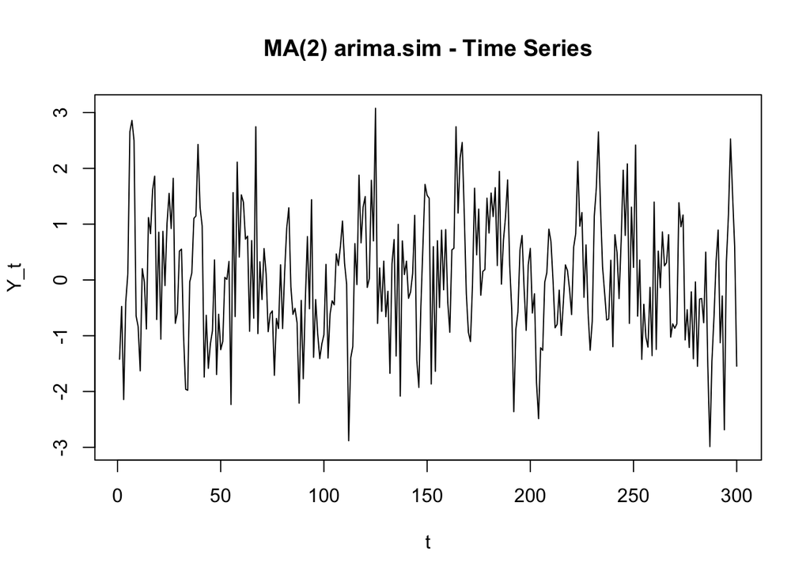

```r
ts.plot(y_ma2_sim, main = "MA(2) arima.sim - Time Series", xlab = "t", ylab = "Y_t")
```

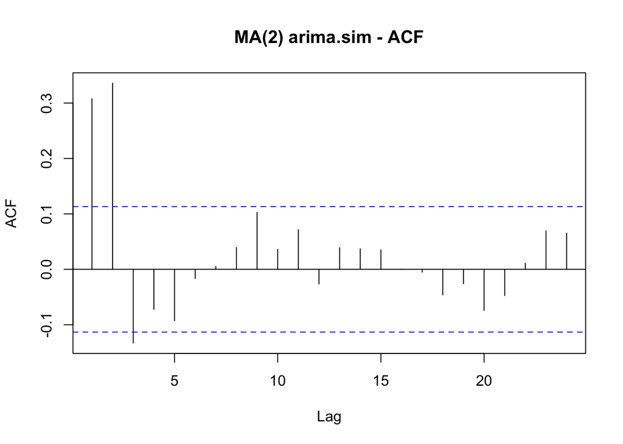

```r
acf(y_ma2_sim,  main = "MA(2) arima.sim - ACF")
```

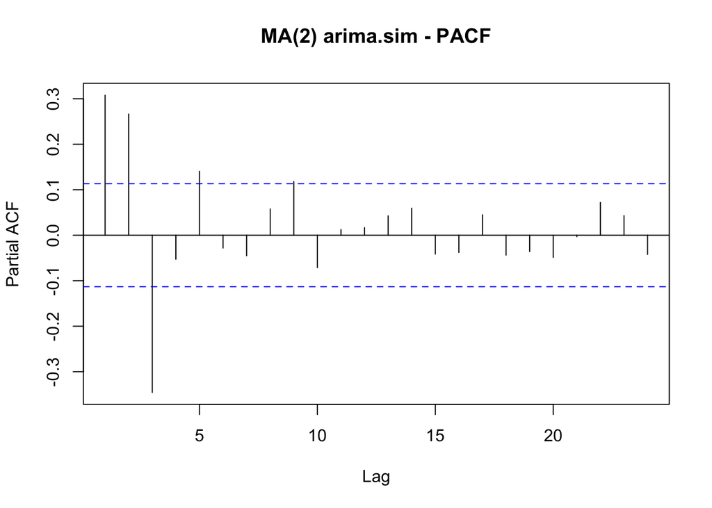

```r
pacf(y_ma2_sim, main = "MA(2) arima.sim - PACF")
```

```r
eacf(y_ma2_sim)
```

```
## AR/MA
##   0 1 2 3 4 5 6 7 8 9 10 11 12 13
## 0 x x x o o o o o o o o  o  o  o
## 1 x x x o o o o o o o o  o  o  o
## 2 x x x x o o o o o o o  o  o  o
## 3 x x x o x o o o o o o  o  o  x
## 4 x x o o o x o o o o o  o  o  o
## 5 x x o o o x x o o o o  o  o  o
## 6 x x o o o x o x o o o  o  o  o
## 7 x x o x x o x x x o o  o  o  o
```

#### Buat scatterplot antara 𝑌𝑡 dengan 𝑌𝑡−1, 𝑌𝑡 dengan 𝑌𝑡−2 serta 𝑌𝑡 dengan 𝑌𝑡−3

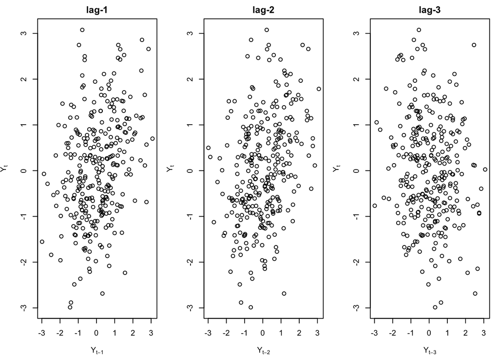

```r
par(mfrow = c(1,3), mar = c(4,4,2,1))
plot(y_ma2_sim[2:n], y_ma2_sim[1:(n-1)],  xlab = expression(Y[t-1]), ylab = expression(Y[t]), main = "lag-1")
plot(y_ma2_sim[3:n], y_ma2_sim[1:(n-2)],  xlab = expression(Y[t-2]), ylab = expression(Y[t]), main = "lag-2")
plot(y_ma2_sim[4:n], y_ma2_sim[1:(n-3)],  xlab = expression(Y[t-3]), ylab = expression(Y[t]), main = "lag-3")
```

```r
par(mfrow = c(1,1))
```

#### Hitung autokorelasi masing masing baik dari data bangkitan maupun secara teoritis

```r
theta1 <- 0.4
theta2 <- 0.6
L <- 20

# Teoritis MA(2)
gamma0 <- 1 + theta1^2 + theta2^2
rho0 <- 1
rho1 <- theta1 * (1 + theta2) / gamma0
rho2 <- theta2 / gamma0
acf_theory <- c(rho0, rho1, rho2, rep(0, L - 2))

# ACF sampel
acf_manual <- safe_acf(y_ma2_manual, L)
acf_sim    <- safe_acf(y_ma2_sim,    L)

lag <- 0:L
tab <- data.frame(
  lag = lag,
  theoretical   = round(acf_theory, 3),
  sample_manual = round(acf_manual, 3),
  sample_sim    = round(acf_sim, 3)
)
kable(tab, caption = "Perbandingan ACF Teoritis vs Sampel MA(2)")
```

Perbandingan ACF Teoritis vs Sampel MA(2)

| lag | theoretical | sample_manual | sample_sim |
| --- | --- | --- | --- |
| 0 | 1.000 | 0.393 | 0.308 |
| 1 | 0.421 | 0.301 | 0.336 |
| 2 | 0.395 | -0.059 | -0.133 |
| 3 | 0.000 | -0.151 | -0.072 |
| 4 | 0.000 | -0.021 | -0.093 |
| 5 | 0.000 | -0.028 | -0.016 |
| 6 | 0.000 | 0.079 | 0.005 |
| 7 | 0.000 | 0.097 | 0.039 |
| 8 | 0.000 | 0.028 | 0.103 |
| 9 | 0.000 | -0.017 | 0.036 |
| 10 | 0.000 | -0.076 | 0.071 |
| 11 | 0.000 | -0.087 | -0.026 |
| 12 | 0.000 | -0.005 | 0.039 |
| 13 | 0.000 | -0.025 | 0.037 |
| 14 | 0.000 | 0.053 | 0.035 |
| 15 | 0.000 | -0.063 | 0.000 |
| 16 | 0.000 | -0.048 | -0.005 |
| 17 | 0.000 | -0.094 | -0.046 |
| 18 | 0.000 | -0.084 | -0.026 |
| 19 | 0.000 | -0.005 | -0.074 |
| 20 | 0.000 | NA | NA |

**ACF teoritis MA(2)** (θ₁ = 0.4, θ₂ = 0.6):

ρ(0) = 1

ρ(1) = 0.421

ρ(2) = 0.395

ρ(k) = 0 untuk k > 2 (**cut-off di lag 2**).

## Proses AR(2)

#### Bangkitkan model AR(2) dengan 𝜙1 = 0.5 dan 𝜙2 = 0.2 sebanyak 300 data (Manual dan dengan arima.sim)

```r
set.seed(123)
phi1 <- 0.5
phi2 <- 0.2
n <- 300

# Manual
# White Noise
wn <- rnorm(n, mean = 0, sd = 1)

y_manual <- numeric(n)

y_manual[1:2] <- wn[1:2]

# proses AR(2): Yt = phi1*Yt-1 + phi2*Yt-2 + et
for(t in 3:n){
  y_manual[t] <- phi1*y_manual[t-1] + phi2*y_manual[t-2] + wn[t]
}

#arima.sim
y_sim <- arima.sim(n = n, model = list(ar = c(phi1, phi2)), sd = 1)
```

#### Buat plot time series, plot ACF, plot PACF dan plot EACF. Idenifikasi apakah data tersebut stasioner

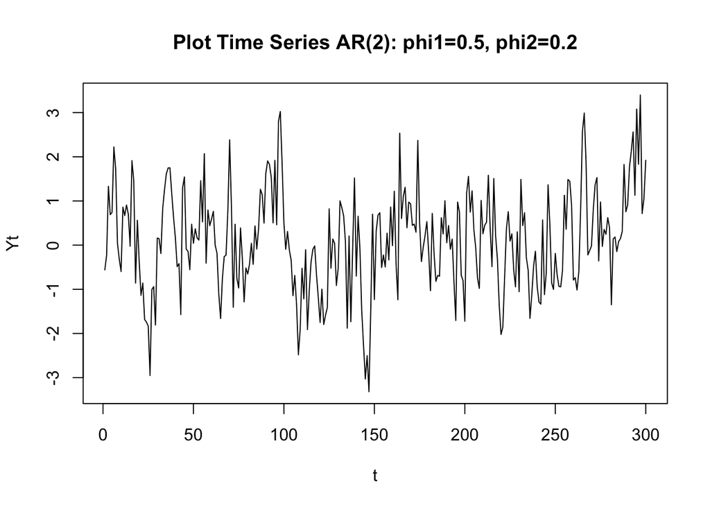

```r
y_ts <- ts(y_manual)
plot.ts(y_ts, main = "Plot Time Series AR(2): phi1=0.5, phi2=0.2",
        ylab = "Yt", xlab = "t")
```

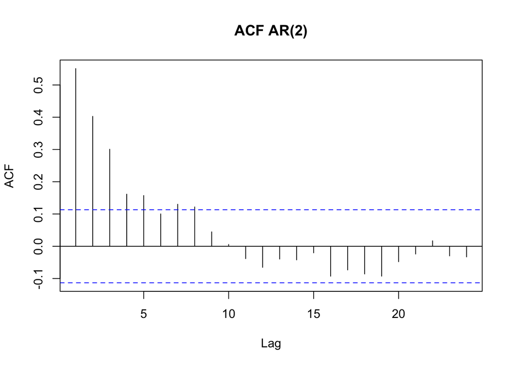

```r
acf(y_ts, main = "ACF AR(2)")
```

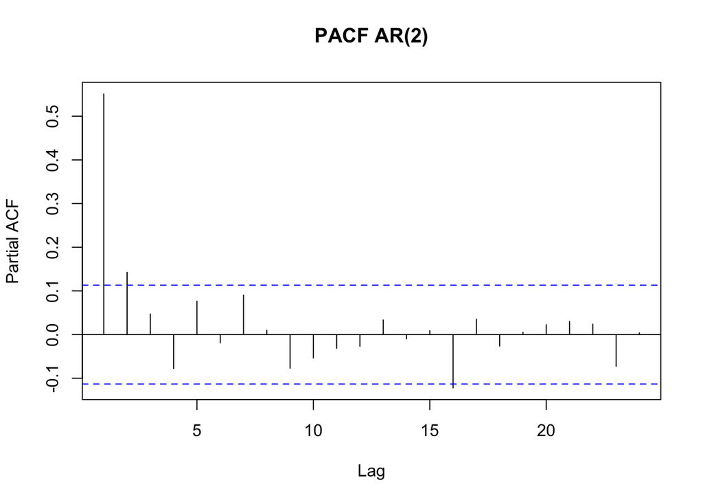

```r
pacf(y_ts, main = "PACF AR(2)")
```

```r
eacf(y_ts)
```

```
## AR/MA
##   0 1 2 3 4 5 6 7 8 9 10 11 12 13
## 0 x x x x x o x x o o o  o  o  o
## 1 x o o x o o o o o o o  o  o  o
## 2 x o o o o o o o o o o  o  o  o
## 3 x o o o o o o o o o o  o  o  o
## 4 x o o o o o o o o o o  o  o  o
## 5 x x o o o o o o o o o  o  o  o
## 6 x x o x x o o o o o o  o  o  o
## 7 x x o x x o x o o o o  o  o  o
```

#### Buat scatterplot antara 𝑌𝑡 dengan 𝑌𝑡−1, 𝑌𝑡 dengan 𝑌𝑡−2 serta 𝑌𝑡 dengan 𝑌𝑡−3

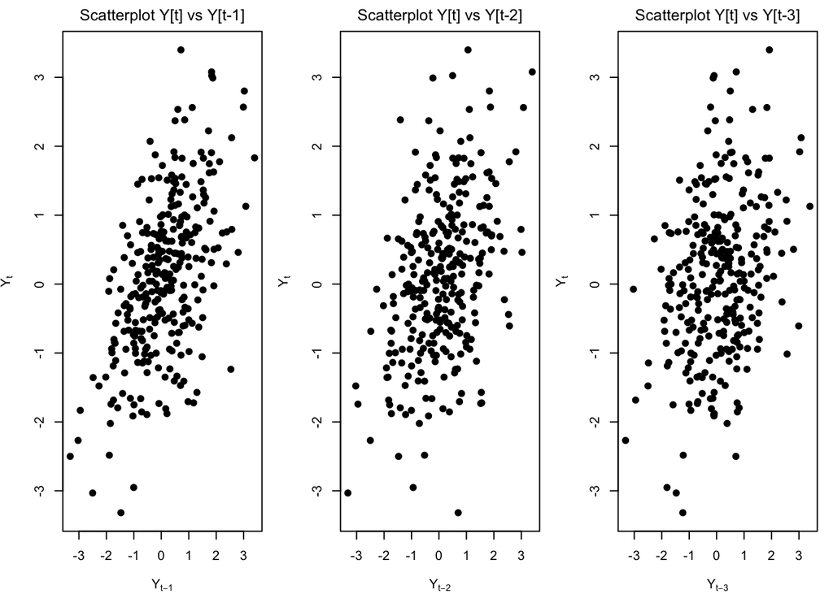

```r
y <- as.numeric(y_manual)
par(mfrow = c(1,3), mar = c(4,4,2,1))
plot(y[2:length(y)], y[1:(length(y)-1)],
     xlab = expression(Y[t-1]), ylab = expression(Y[t]),
     main = expression("Scatterplot Y[t] vs Y[t-1]"),
     pch = 19)
plot(y[3:length(y)], y[1:(length(y)-2)],
     xlab = expression(Y[t-2]), ylab = expression(Y[t]),
     main = expression("Scatterplot Y[t] vs Y[t-2]"),
     pch = 19)
plot(y[4:length(y)], y[1:(length(y)-3)],
     xlab = expression(Y[t-3]), ylab = expression(Y[t]),
     main = expression("Scatterplot Y[t] vs Y[t-3]"),
     pch = 19)
```

#### Hitung autokorelasi masing masing baik dari data bangkitan maupun secara teoritis

```r
phi1 <- 0.5
phi2 <- 0.2
L <- 20

# Teoritis
phi1 <- 0.5; phi2 <- 0.2; L <- 20
rho <- numeric(L+1)
rho[1] <- 1
rho[2] <- phi1 / (1 - phi2)
rho[3] <- phi1 * rho[2] + phi2 * rho[1]
for (k in 3:L) {
  rho[k+1] <- phi1 * rho[k] + phi2 * rho[k-1]
}
acf_theory <- rho

a1 <- acf(y_manual, lag.max = L, plot = FALSE, demean = TRUE)
a2 <- acf(y_sim,    lag.max = L, plot = FALSE, demean = TRUE)

v1 <- as.numeric(a1$acf)
v2 <- as.numeric(a2$acf)
K  <- min(length(v1), length(v2), L + 1)
lag <- 0:(K-1)

tab <- data.frame(
  lag = lag,
  theoretical = round(acf_theory[1:K], 3),
  sample_manual = round(v1[1:K], 3),
  sample_sim    = round(v2[1:K], 3)
)

kable(tab, caption = "Perbandingan ACF Teoritis vs Sampel AR(2)")
```

Perbandingan ACF Teoritis vs Sampel AR(2)

| lag | theoretical | sample_manual | sample_sim |
| --- | --- | --- | --- |
| 0 | 1.000 | 0.551 | 0.514 |
| 1 | 0.625 | 0.403 | 0.435 |
| 2 | 0.512 | 0.301 | 0.303 |
| 3 | 0.381 | 0.161 | 0.244 |
| 4 | 0.293 | 0.157 | 0.155 |
| 5 | 0.223 | 0.100 | 0.162 |
| 6 | 0.170 | 0.130 | 0.129 |
| 7 | 0.130 | 0.122 | 0.119 |
| 8 | 0.099 | 0.045 | 0.132 |
| 9 | 0.075 | 0.006 | 0.100 |
| 10 | 0.057 | -0.038 | 0.115 |
| 11 | 0.044 | -0.065 | 0.057 |
| 12 | 0.033 | -0.040 | 0.108 |
| 13 | 0.025 | -0.042 | 0.124 |
| 14 | 0.019 | -0.020 | 0.076 |
| 15 | 0.015 | -0.093 | 0.039 |
| 16 | 0.011 | -0.073 | 0.021 |
| 17 | 0.009 | -0.086 | -0.006 |
| 18 | 0.007 | -0.093 | -0.003 |
| 19 | 0.005 | -0.048 | -0.030 |

**ACF teoritis AR(2) (**phi1=0.5, phi2=0.2**):**

rho(0) = 1

rho(1) = 0.625

rho(2) = 0.512

rho(3) = 0.381

rho(4) = 0.293

dst. nilai autokorelasi **meluruh bertahap (tail-off)**, tidak terpotong.

**ACF sampel (dari y_manual maupun y_sim)** mendekati nilai teoritis:

- Lag 1 dan 2 cukup besar dan positif.
- Lag berikutnya makin kecil dan berfluktuasi di sekitar 0.
- Perbedaan kecil muncul karena ukuran sampel terbatas (n=300), bahkan ada nilai negatif pada sampel meskipun teoritisnya positif.
- Sesuai teori, model AR(2) menghasilkan ACF yang **tail-off** dan **stasioner**. Pola ini konsisten dengan sifat AR(p): PACF terpotong di lag 2, sedangkan ACF meluruh secara bertahap.

## Proses ARMA(2,2)

#### Bangkitkan model ARMA(2,2) dengan 𝜃1 = 0.4, 𝜃2 = 0.6 , 𝜙1 = 0.5 dan 𝜙2 = 0.2 sebanyak 300 data (Manual dan arima.sim)

```r
set.seed(123)


phi1 <- 0.5
phi2 <- 0.2
theta1 <- 0.4
theta2 <- 0.6
n <- 300

# Manual
wn <- rnorm(n, 0, 1)
y_manual <- numeric(n)

y_manual[1:2] <- wn[1:2]

# ARMA(2,2): Yt = φ1 Yt-1 + φ2 Yt-2 + et + θ1 et-1 + θ2 et-2
for (t in 3:n){
  y_manual[t] <- phi1*y_manual[t-1] + phi2*y_manual[t-2] +
                 wn[t] + theta1*wn[t-1] + theta2*wn[t-2]
}

# arima.sim
y_sim <- arima.sim(n = n,
                   model = list(ar = c(phi1, phi2),
                                ma = c(theta1, theta2)),
                   sd = 1)
```

#### Buat plot time series, plot ACF, plot PACF dan plot EACF. Idenifikasi apakah data tersebut stasioner

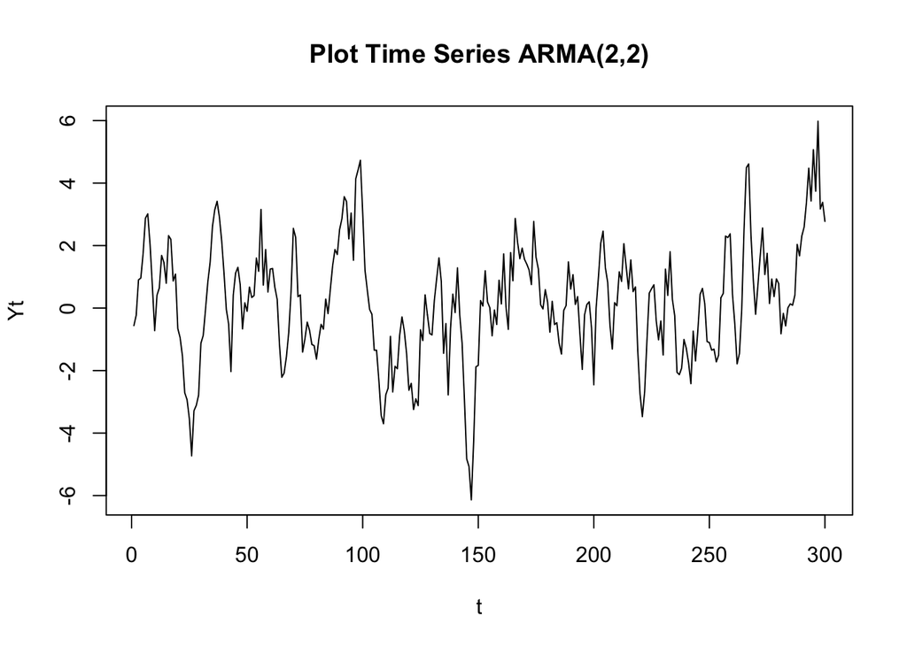

```r
y_ts <- ts(y_manual)
plot.ts(y_ts, main="Plot Time Series ARMA(2,2)", ylab="Yt", xlab="t")
```

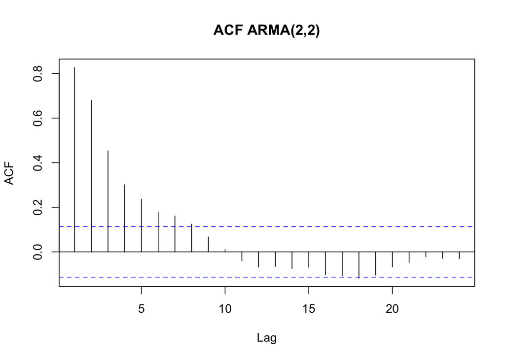

```r
acf(y_ts, main="ACF ARMA(2,2)")
```

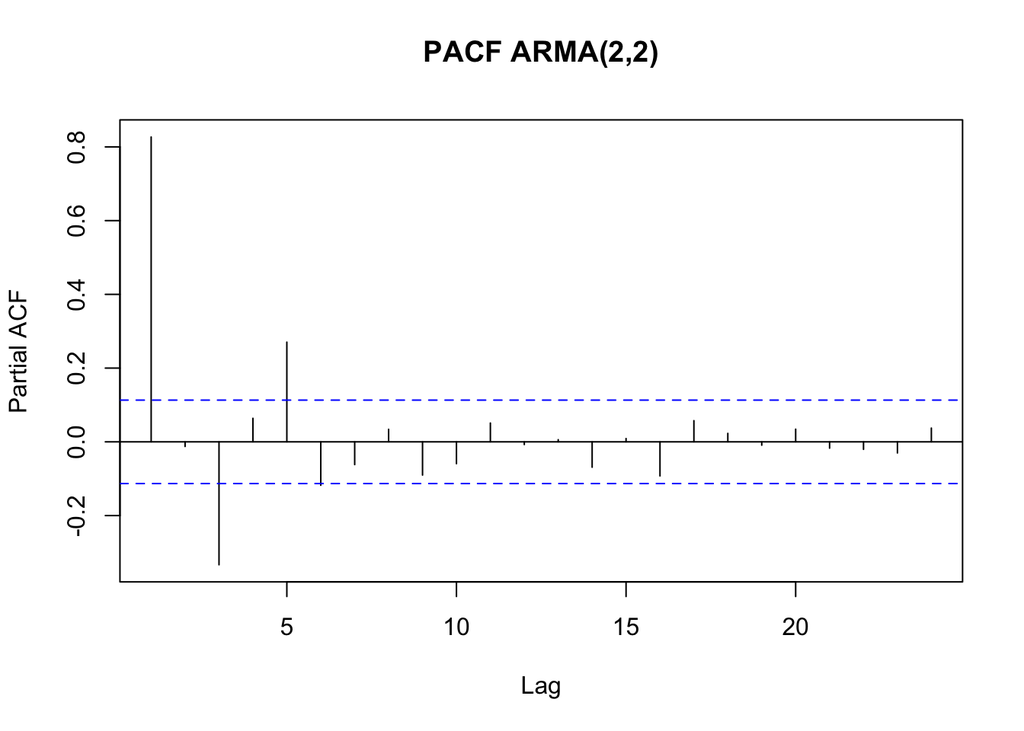

```r
pacf(y_ts, main="PACF ARMA(2,2)")
```

```r
eacf(y_ts)
```

```
## AR/MA
##   0 1 2 3 4 5 6 7 8 9 10 11 12 13
## 0 x x x x x x x x o o o  o  o  o
## 1 o x o x o o o o o o o  o  o  o
## 2 o x o x o o o o o o o  o  o  o
## 3 x x o x o o o x o o o  o  o  o
## 4 x x o x o o o x o o o  o  o  o
## 5 x x o x x o o o o o o  o  o  o
## 6 x x o x o o o o o o o  o  o  o
## 7 x o x x x o o o o o o  o  o  o
```

#### Buat scatterplot antara 𝑌𝑡 dengan 𝑌𝑡−1, 𝑌𝑡 dengan 𝑌𝑡−2 serta 𝑌𝑡 dengan 𝑌𝑡−3

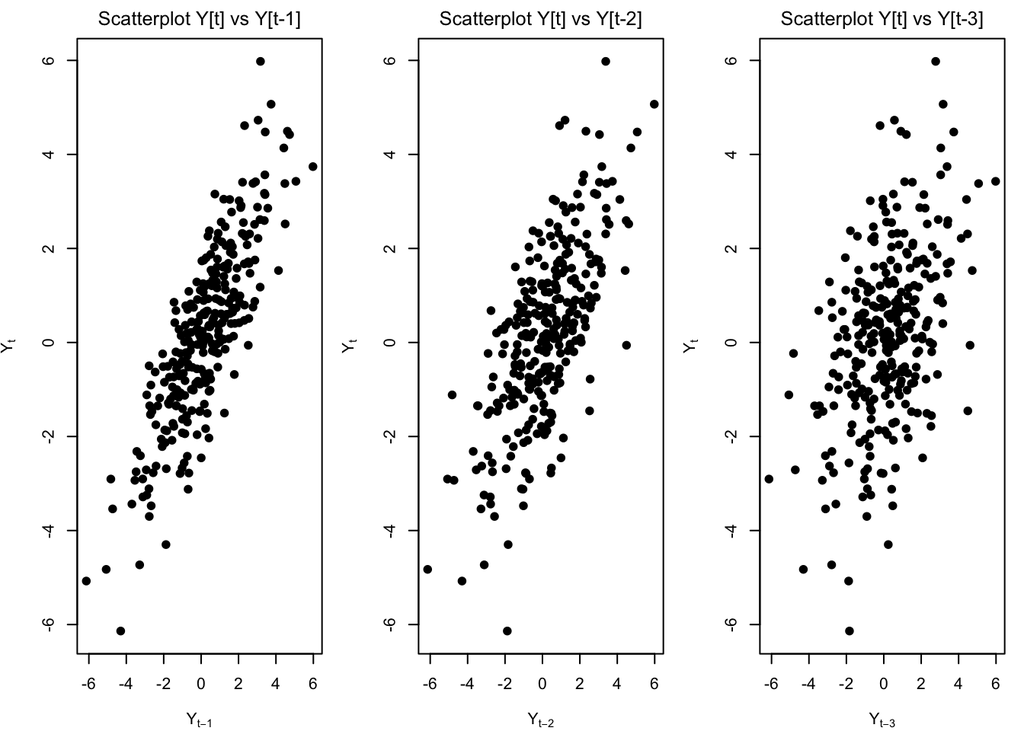

```r
y <- as.numeric(y_manual)
par(mfrow = c(1,3), mar = c(4,4,2,1))
plot(y_manual[-1], y_manual[-length(y_manual)],
     xlab=expression(Y[t-1]), ylab=expression(Y[t]),
     main=expression("Scatterplot Y[t] vs Y[t-1]"),
     pch=19)
plot(y_manual[-c(1,2)], y_manual[1:(length(y_manual)-2)],
     xlab=expression(Y[t-2]), ylab=expression(Y[t]),
     main=expression("Scatterplot Y[t] vs Y[t-2]"),
     pch=19)
plot(y_manual[-c(1,2,3)], y_manual[1:(length(y_manual)-3)],
     xlab=expression(Y[t-3]), ylab=expression(Y[t]),
     main=expression("Scatterplot Y[t] vs Y[t-3]"),
     pch=19)
```

#### Hitung autokorelasi masing masing baik dari data bangkitan maupun secara teoritis

```r
phi1 <- 0.5; phi2 <- 0.2; theta1 <- 0.4; theta2 <- 0.6; L <- 20
M <- 100
psi <- numeric(M)
psi[1] <- 1
psi[2] <- theta1 + phi1
psi[3] <- theta2 + phi1*psi[2] + phi2*psi[1]
for (j in 4:M){
  psi[j] <- phi1*psi[j-1] + phi2*psi[j-2]
}
gamma <- numeric(L+1)
for (k in 0:L){
  gamma[k+1] <- sum(psi[1:(M-k)] * psi[(1+k):M])
}
rho_theory <- gamma / gamma[1]

acf_manual <- as.numeric(acf(y_manual, lag.max=L, plot=FALSE)$acf)
acf_sim    <- as.numeric(acf(y_sim,    lag.max=L, plot=FALSE)$acf)

K <- min(length(acf_manual), length(acf_sim), L+1)
lag <- 0:(K-1)

tab <- data.frame(
  lag = lag,
  theoretical = round(rho_theory[1:K], 3),
  sample_manual = round(acf_manual[1:K], 3),
  sample_sim    = round(acf_sim[1:K], 3)
)

kable(tab, caption = "Perbandingan ACF Teoritis vs Sampel ARMA(2,2)")
```

Perbandingan ACF Teoritis vs Sampel ARMA(2,2)

| lag | theoretical | sample_manual | sample_sim |
| --- | --- | --- | --- |
| 0 | 1.000 | 0.827 | 0.810 |
| 1 | 0.859 | 0.680 | 0.712 |
| 2 | 0.749 | 0.453 | 0.476 |
| 3 | 0.546 | 0.301 | 0.373 |
| 4 | 0.423 | 0.236 | 0.274 |
| 5 | 0.321 | 0.178 | 0.235 |
| 6 | 0.245 | 0.161 | 0.198 |
| 7 | 0.187 | 0.124 | 0.181 |
| 8 | 0.142 | 0.067 | 0.177 |
| 9 | 0.109 | 0.010 | 0.153 |
| 10 | 0.083 | -0.040 | 0.158 |
| 11 | 0.063 | -0.068 | 0.138 |
| 12 | 0.048 | -0.065 | 0.147 |
| 13 | 0.037 | -0.075 | 0.133 |
| 14 | 0.028 | -0.069 | 0.106 |
| 15 | 0.021 | -0.103 | 0.065 |
| 16 | 0.016 | -0.108 | 0.028 |
| 17 | 0.012 | -0.118 | -0.004 |
| 18 | 0.009 | -0.104 | -0.014 |
| 19 | 0.007 | -0.068 | -0.020 |

**ACF teoritis ARMA(2,2) (**phi1 = 0.5, phi2 = 0.2, theta1 = 0.4, theta2 = 0.6**):**

rho(0) = 1

rho(1) = 0.859

rho(2) = 0.749

rho(3) = 0.546

rho(4) = 0.423

dst. nilai autokorelasi **meluruh bertahap (tail–off)**, tidak terpotong pada lag tertentu.

**ACF sampel (dari y_manual maupun y_sim)** mendekati nilai teoritis: